# (homework) 05_exercise_transfer_learning_with_tensorflow_part_2

### 🛠 Exercises

1. Write a function to visualize an image from any dataset (train or test file) and any class (e.g. "steak", "pizza"... etc), visualize it and make a prediction on it using a trained model.
2. Use feature-extraction to train a transfer learning model on 10% of the Food Vision data for 10 epochs using tf.keras.applications.efficientnet_v2.EfficientNetV2B0 as the base model. Use the ModelCheckpoint callback to save the weights to file.
3. Fine-tune the last 20 layers of the base model you trained in 2 for another 10 epochs. How did it go?
4. Fine-tune the last 30 layers of the base model you trained in 2 for another 10 epochs. How did it go?

### 1. Write function to visualize an image from any dataset (train or test) and any class ('steak', 'pizza'), and have it be visualized, with prediction made on it with a trained model

Based on what they want us to accomplish, we need the following variables for our function:

- File directory/location
- Photo class
- Model of choice
1. Use `random` for `random.choice` to select a random image from the class that was specified.
2. Create the image directory path, from the specified directory
3. Use `mpimg.imread` to 'read' the image, aka getting it to be displayed
4. Get inputed model to predict the specified image
5. Use `plt` to plot the image, and annotate over the picture with the prediction, and actual label

Before any function creation, I will first write the code out as I would step by step, then aggregate them into a final function, once a desired result is met.

#### Create directory of data

We will use the `10 percent` data for directory location, as this is the only directory where I kept the `test` folder. the `1 percent` and `all` data test folders have been deleted to save storage space, as they are identical to each other.

```python
# create variable to train and test folder directory
train_dir = '10_food_classes_10_percent/train/'
test_dir = '10_food_classes_10_percent/test/'
```

#### Create exact model, that the weights are saved to

Instead of a simple copy paste situation for the model and it's layers, we've only done the checkpoint of the model, so will have to create the body from scratch again as practice.

```python
# recreate the model to load the weights into
import tensorflow as tf
from tensorflow import keras
from tensorflow.keras import layers
from tensorflow.keras.models import Sequential

# augmentation layer for training
data_augmentation = keras.Sequential([
    layers.RandomFlip('horizontal'),
    layers.RandomRotation(0.2),
    layers.RandomZoom(0.2),
    layers.RandomHeight(0.2),
    layers.RandomWidth(0.2),
], name='data_augmentation'
)

# setup input shape
input_shape = (224,224,3)

# create frozen base model layer
base_model = tf.keras.applications.efficientnet_v2.EfficientNetV2B0(include_top=False)
base_model.trainable=False

# create input and output layers
inputs = layers.Input(shape=input_shape, name='input_layer') # create input layer for the incoming images
x = data_augmentation(inputs) # put input shape into data augmentation
x = base_model(x, training=False) # pass augmented images into base_model, which layers are frozen
x = layers.GlobalAveragePooling2D(name='global_average_pooling_layer')(x) # average pool the results of the image into its colour channels, so it's 1 dimensional and can be passed towards output layer
outputs = layers.Dense(10, activation='softmax', name='output_layer')(x) # output layer, consisting of 10 categories from our problem
model = tf.keras.Model(inputs, outputs)

# compile model
model.compile(loss='categorical_crossentropy',
              optimizer=tf.keras.optimizers.Adam(learning_rate=0.001),
              metrics=['accuracy'])
```

#### Load model checkpoint

To save time in terms of model building and training, we will utilise the checkpoint that was created from the study materials, where our model had the time to fit into the data that was presented to it.

We will get the file location, and use `.load_weights`

```python
# load model weights and find the model checkpoint
checkpoint_path = 'ten_percent_model_checkpoints_weights/checkpoint.weights.h5'
model.load_weights(checkpoint_path)
```

#### Test the model, and import image dataset

Let's quickly test the model on a random image from the test folder. But to do so, we will also need to import the image dataset, and transpose it correctly, so the model can read it as well.

- To create train and test, use `image_dataset_from_directory()` method
- Create `train_data`, and label mode is set to categorical, add batch size 32, and image size to (224,224,3)
- Create `test_data` like train data, but without batch size
- Use `random.choice` to pick a random class, and a random image
- Use `mpimg.imread` to read image, and have it be plotted via `matplotlib`
- Fit the model on the specific image that was selected, and print it's prediction, with the accompanied true class label

Now let's start step 1 with creating the train and test data for the model, with the directory that was set up before with the `10% data`.

```python
# create train and test data
IMG_SIZE=(224,224)
train_data = tf.keras.preprocessing.image_dataset_from_directory(train_dir,
                                                                 label_mode='categorical',
                                                                 batch_size=32,
                                                                 image_size=IMG_SIZE)

test_data = tf.keras.preprocessing.image_dataset_from_directory(test_dir,
                                                                label_mode='categorical',
                                                                image_size=IMG_SIZE)
```

```
Found 750 files belonging to 10 classes.
Found 2500 files belonging to 10 classes.
```

I want to quickly check the list of class names in our data with `.class_names`

```python
train_data.class_names
```

```
['chicken_curry',
 'chicken_wings',
 'fried_rice',
 'grilled_salmon',
 'hamburger',
 'ice_cream',
 'pizza',
 'ramen',
 'steak',
 'sushi']
```

let's use `random.choice` to select a random image for us to use. Make sure we save the directory location as well, so they can be pulled out for plotting/visualizing

```python
# pick random class and image to use for model prediction
# also save the directory location for random image
import random
import os

target_class = random.choice(test_data.class_names) # select random data class
target_dir = test_dir + target_class # create directory folder location for the randomly selected class
random_image = random.choice(os.listdir(target_dir)) # from target directory, select a random file within said directory
random_image_path = target_dir + '/' + random_image # creating directory location for said selected random file
random_image_path
```

```
'10_food_classes_10_percent/test/grilled_salmon/397512.jpg'
```

Now we have the location of a random selected image, or a randomly selected class, let's try visualize the image with `matplotlib`.

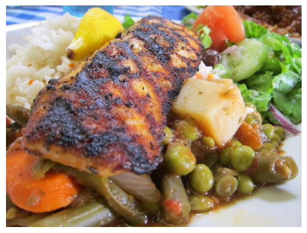

```python
# plot out the randomly selected image
import matplotlib.pyplot as plt
import matplotlib.image as mpimg

img = mpimg.imread(random_image_path) # read image from file path
plt.imshow(img) # show image onto plot
plt.axis(False); # prevent the x and y axis plot from showing
```

Lastly, let's have the model guess the class of the image above, and also print out the target class as well.

```python
# predict the image class with our loaded in model

processed_img = tf.image.resize(img, (224,224)) # resize image so it fits the shape, the model is accustomed to for training
pred = model.predict(tf.expand_dims(processed_img,axis=0)) # expanding dimension of image to work with model
# prediction gives us a probability list of all the classes. We will only select the probability thats the highest out of the list

test_data.class_names[pred.argmax()],target_class # find the max value probability in the list of prediction, and apply it onto class_names, via the index location of max
```

```
1/1 ━━━━━━━━━━━━━━━━━━━━ 0s 70ms/step
```

```
('grilled_salmon', 'grilled_salmon')
```

Sweet! Everything has worked. Now it's time to create a function out of what was typed out.

```python
# create function that calls for data folder (train/test), class name, and chosen model
def predict_image(data, class_name, model):

    target_dir = '10_food_classes_10_percent/' + data + '/' + class_name # create target directory with inputted data type, and class
    random_image = random.choice(os.listdir(target_dir)) # select a random image from said dir
    random_image_path = target_dir + '/' + random_image # create directory location of said random img

    img = mpimg.imread(random_image_path) # read image
    plt.imshow(img) # show image via plt
    plt.axis(False); # remove numbered x and y axis

    processed_img = tf.image.resize(img, (224,224)) # preprocess img for the model to read
    pred = model.predict(tf.expand_dims(processed_img,axis=0)) # image is expanded to fit model's input shape, and is predicted on

    print(f'Prediction of class: {test_data.class_names[pred.argmax()]} \n True class: {class_name}') # print the result with the highest probability out of all classes, and also the true class
```

Now let's test the function out

```
1/1 ━━━━━━━━━━━━━━━━━━━━ 0s 70ms/step
Prediction of class: grilled_salmon
 True class: sushi
```

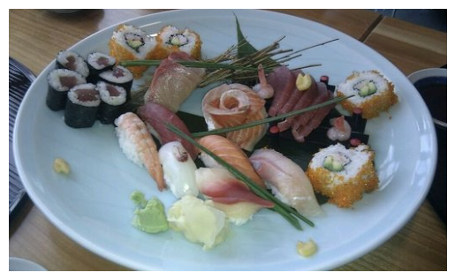

```python
predict_image('test','sushi',model)
```

```
1/1 ━━━━━━━━━━━━━━━━━━━━ 0s 69ms/step
Prediction of class: grilled_salmon
 True class: grilled_salmon
```

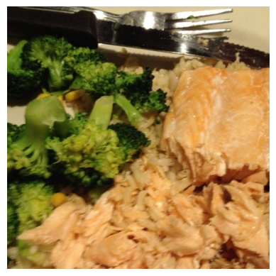

```python
predict_image('train','grilled_salmon',model)
```

### 2. Use feature-extraction to train a transfer learning model on 10% of the Food Vision data for 10 epochs using tf.keras.applications.efficientnet_v2.EfficientNetV2B0 as the base model. Use the ModelCheckpoint callback to save the weights to file.

We have the loaded weights of model_2, which is a feature_extracted model that was trained on 10% of the data for 5 epochs. If we wanted 10 epochs of training, then we can continue where it left off, and train another 5 epochs on it.

Let's evaluate the model and check that it is checkpointed and have the values of '[0.7025160193443298, 0.8163999915122986]'.

```python
# check evaluation values and that it matches/is close to the number above
model.evaluate(test_data)
```

```
79/79 ━━━━━━━━━━━━━━━━━━━━ 36s 324ms/step - accuracy: 0.8164 - loss: 0.7025
```

```
[0.7025159001350403, 0.8163999915122986]
```

Let's feature extract another 5 epochs, and create a `.fit` on the model

```python
!curl -O https://raw.githubusercontent.com/mrdbourke/tensorflow-deep-learning/main/extras/helper_functions.py
from helper_functions import create_tensorboard_callback, plot_loss_curves, unzip_data, walk_through_dir
```

```
  % Total    % Received % Xferd  Average Speed   Time    Time     Time  Current
                                 Dload  Upload   Total   Spent    Left  Speed

  0     0    0     0    0     0      0      0 --:--:-- --:--:-- --:--:--     0
100 10246  100 10246    0     0   173k      0 --:--:-- --:--:-- --:--:--  181k
```

```python
# continue to train the model for 5 more epochs

history_10_percent = model.fit(train_data,
                               epochs=5,
                               validation_data=test_data,
                               validation_steps=int(0.25 * len(test_data)), # go through less of test data (a quarter) to speed up experiment phase
                               callbacks=[create_tensorboard_callback('transfer_learning','10_percent_classes')])
```

```
Saving TensorBoard log files to: transfer_learning/10_percent_classes/20251014-204854
24/24 ━━━━━━━━━━━━━━━━━━━━ 35s 861ms/step - accuracy: 0.7840 - loss: 0.8367 - val_accuracy: 0.8174 - val_loss: 0.6620
24/24 ━━━━━━━━━━━━━━━━━━━━ 20s 825ms/step - accuracy: 0.7907 - loss: 0.7433 - val_accuracy: 0.8487 - val_loss: 0.5666
24/24 ━━━━━━━━━━━━━━━━━━━━ 19s 793ms/step - accuracy: 0.8147 - loss: 0.6878 - val_accuracy: 0.8438 - val_loss: 0.5581
24/24 ━━━━━━━━━━━━━━━━━━━━ 18s 757ms/step - accuracy: 0.8293 - loss: 0.6334 - val_accuracy: 0.8569 - val_loss: 0.5306
24/24 ━━━━━━━━━━━━━━━━━━━━ 17s 720ms/step - accuracy: 0.8467 - loss: 0.6086 - val_accuracy: 0.8569 - val_loss: 0.5122
```

Since I haven't saved the first 5 epoch history as some accessible data in my folder, I've copy pasted the graph from the study material, to then compare it to us, training for another 5 epochs, to reach 10 epochs trained.

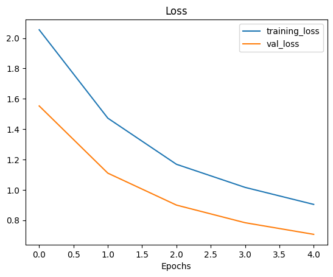

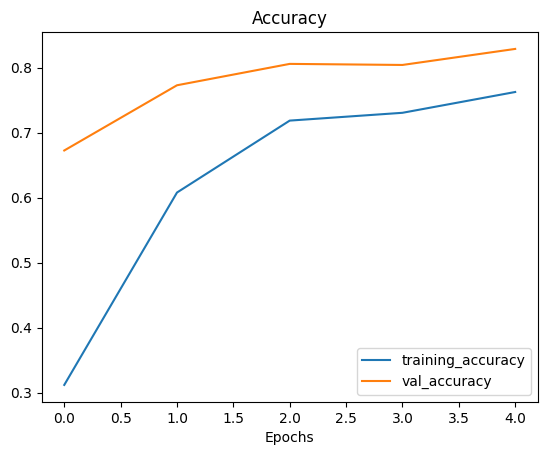

```python
from IPython.display import Image, display

display(Image(filename="0581f5d1-8917-4c64-8986-5c3104d02418.png"))
display(Image(filename="07f7c8cf-93f5-4d73-b7ff-f1c88679eaf5.png"))
```

Now let's visualize the epochs 6-10 with `plot_loss_curves`, which were added via our `helper.py` code

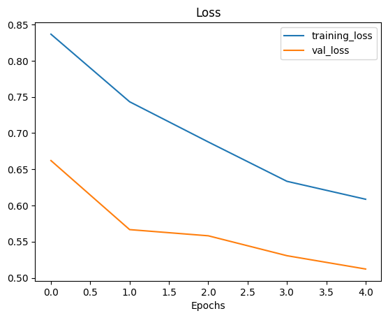

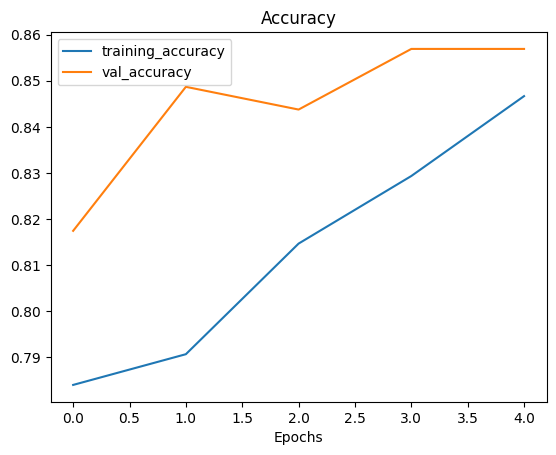

```python
# check out model's epoch 6-10 history
plot_loss_curves(history_10_percent)
```

The model has showed further improvements beyond epoch 6, but it does seem like it's significantly slowed down in the amount it can improve upon (as the ceiling appears to be around 85% for `val_data`).

Now it's time to create a checkpoint for the model again.

> **Note**: Forgotten to create a checkpoint callback before, and didn't add it to the model. So will have to retrain the model again for it to checkpoint and save onto our folder. Lol

```python
# create a callbackcheckpoint to save model weight during training
checkpoint_callback = tf.keras.callbacks.ModelCheckpoint(filepath=checkpoint_path,
                                                         save_weights_only=True, # set false if saving whole model
                                                         save_best_only=True, # save only the best, rather than a separate model for every time this runs
                                                         save_freq='epoch', # frequency of model being saved
                                                         verbose=1)
```

```python
# continue to train the model for 5 more epochs

history_10_percent = model.fit(train_data,
                               epochs=5,
                               validation_data=test_data,
                               validation_steps=int(0.25 * len(test_data)), # go through less of test data (a quarter) to speed up experiment phase
                               callbacks=[create_tensorboard_callback('transfer_learning','10_percent_classes'), checkpoint_callback])
```

```
Saving TensorBoard log files to: transfer_learning/10_percent_classes/20251014-211359
24/24 ━━━━━━━━━━━━━━━━━━━━ 0s 424ms/step - accuracy: 0.8591 - loss: 0.5461
Epoch 1: val_loss improved from None to 0.49723, saving model to ten_percent_model_checkpoints_weights/checkpoint.weights.h5
24/24 ━━━━━━━━━━━━━━━━━━━━ 18s 759ms/step - accuracy: 0.8453 - loss: 0.5697 - val_accuracy: 0.8503 - val_loss: 0.4972
24/24 ━━━━━━━━━━━━━━━━━━━━ 0s 457ms/step - accuracy: 0.8327 - loss: 0.5880
Epoch 2: val_loss improved from 0.49723 to 0.46559, saving model to ten_percent_model_checkpoints_weights/checkpoint.weights.h5
24/24 ━━━━━━━━━━━━━━━━━━━━ 20s 872ms/step - accuracy: 0.8333 - loss: 0.5719 - val_accuracy: 0.8701 - val_loss: 0.4656
24/24 ━━━━━━━━━━━━━━━━━━━━ 0s 557ms/step - accuracy: 0.8572 - loss: 0.5366
Epoch 3: val_loss improved from 0.46559 to 0.45362, saving model to ten_percent_model_checkpoints_weights/checkpoint.weights.h5
24/24 ━━━━━━━━━━━━━━━━━━━━ 22s 917ms/step - accuracy: 0.8720 - loss: 0.5137 - val_accuracy: 0.8668 - val_loss: 0.4536
24/24 ━━━━━━━━━━━━━━━━━━━━ 0s 444ms/step - accuracy: 0.8953 - loss: 0.4684
Epoch 4: val_loss improved from 0.45362 to 0.43778, saving model to ten_percent_model_checkpoints_weights/checkpoint.weights.h5
24/24 ━━━━━━━━━━━━━━━━━━━━ 18s 779ms/step - accuracy: 0.8813 - loss: 0.4909 - val_accuracy: 0.8651 - val_loss: 0.4378
24/24 ━━━━━━━━━━━━━━━━━━━━ 0s 443ms/step - accuracy: 0.8673 - loss: 0.4798
Epoch 5: val_loss improved from 0.43778 to 0.43009, saving model to ten_percent_model_checkpoints_weights/checkpoint.weights.h5
24/24 ━━━━━━━━━━━━━━━━━━━━ 18s 769ms/step - accuracy: 0.8627 - loss: 0.4920 - val_accuracy: 0.8668 - val_loss: 0.4301
```

### 3. Fine-tune the last 20 layers of the base model you trained in 2 for another 10 epochs.

To do this, we will need to get to the `base_model` of our model, and unfreeze the last 20 layers of the model. Since the model has been changed, we have to make sure that we compile the model again, or else the changes we've made won't save to the model.

The following steps:

```python
# check model layers and see where base model is
model.layers
```

```
[<InputLayer name=input_layer, built=True>,
 <Sequential name=data_augmentation, built=True>,
 <Functional name=efficientnetv2-b0, built=True>,
 <GlobalAveragePooling2D name=global_average_pooling_layer, built=True>,
 <Dense name=output_layer, built=True>]
```

```python
# find base model location
base_model_loc = model.layers[2] # base model is at index 2 of model
```

```python
# unfreeze last 20 layers, aka top of the model
for layer in base_model_loc.layers[-21:]: # extra index to account for starting number not being included
    layer.trainable=True

# recompile the model to save changes
model.compile(loss='categorical_crossentropy',
              optimizer=tf.keras.optimizers.Adam(learning_rate=0.0001), # adam learning rate dropped 10x to not heavily affect weights that are pre-set on model.
              metrics=['accuracy'])
```

Let's check the layer's trainable status, by creating a `for` loop through the entire base model.

```python
# check trainability of layers in base model
for layer_number, layer in enumerate(base_model_loc.layers):
    print(layer_number, layer.name, layer.trainable)
```

```
0 input_layer_6 False
1 rescaling_3 False
2 normalization_3 False
3 stem_conv False
4 stem_bn False
5 stem_activation False
6 block1a_project_conv False
7 block1a_project_bn False
8 block1a_project_activation False
9 block2a_expand_conv False
10 block2a_expand_bn False
11 block2a_expand_activation False
12 block2a_project_conv False
13 block2a_project_bn False
14 block2b_expand_conv False
```

[output cut: 255 more lines]

```python
print(len(model.trainable_variables))
```

```
20
```

```python
# continue 10 more epoch training, on the now 20 layer, fine tune model
fine_tuning_epochs = 5+10

history_fine_tune_20_layers = model.fit(train_data,
          epochs=fine_tuning_epochs,
          validation_data=test_data,
          initial_epoch=history_10_percent.epoch[-1],
          validation_steps=int(0.25 * len(test_data)),
          callbacks=[create_tensorboard_callback('transfer_learning', '10_percent_classes')])
```

```
Saving TensorBoard log files to: transfer_learning/10_percent_classes/20251015-220734
24/24 ━━━━━━━━━━━━━━━━━━━━ 38s 903ms/step - accuracy: 0.8453 - loss: 0.6758 - val_accuracy: 0.8651 - val_loss: 0.5027
24/24 ━━━━━━━━━━━━━━━━━━━━ 17s 707ms/step - accuracy: 0.8520 - loss: 0.6003 - val_accuracy: 0.8487 - val_loss: 0.5042
24/24 ━━━━━━━━━━━━━━━━━━━━ 17s 701ms/step - accuracy: 0.8747 - loss: 0.5408 - val_accuracy: 0.8454 - val_loss: 0.4936
24/24 ━━━━━━━━━━━━━━━━━━━━ 17s 718ms/step - accuracy: 0.8707 - loss: 0.5438 - val_accuracy: 0.8569 - val_loss: 0.4701
24/24 ━━━━━━━━━━━━━━━━━━━━ 18s 746ms/step - accuracy: 0.8853 - loss: 0.4947 - val_accuracy: 0.8470 - val_loss: 0.4708
24/24 ━━━━━━━━━━━━━━━━━━━━ 17s 729ms/step - accuracy: 0.8907 - loss: 0.4452 - val_accuracy: 0.8586 - val_loss: 0.4234
24/24 ━━━━━━━━━━━━━━━━━━━━ 18s 761ms/step - accuracy: 0.8827 - loss: 0.4636 - val_accuracy: 0.8651 - val_loss: 0.4189
24/24 ━━━━━━━━━━━━━━━━━━━━ 19s 792ms/step - accuracy: 0.9107 - loss: 0.4177 - val_accuracy: 0.8470 - val_loss: 0.4348
24/24 ━━━━━━━━━━━━━━━━━━━━ 21s 885ms/step - accuracy: 0.9147 - loss: 0.3987 - val_accuracy: 0.8569 - val_loss: 0.4311
24/24 ━━━━━━━━━━━━━━━━━━━━ 22s 923ms/step - accuracy: 0.9200 - loss: 0.3711 - val_accuracy: 0.8553 - val_loss: 0.4152
24/24 ━━━━━━━━━━━━━━━━━━━━ 21s 873ms/step - accuracy: 0.9160 - loss: 0.3687 - val_accuracy: 0.8602 - val_loss: 0.4227
```

Let's evaluate it on the full test data, and see it's result for unfreezing only 20 layers from the top of the model.

```python
# evaluate the 20 layer fine tune model
results_fine_tune_20_layers = model.evaluate(test_data)
```

```
79/79 ━━━━━━━━━━━━━━━━━━━━ 30s 374ms/step - accuracy: 0.8708 - loss: 0.4119
```

Doesn't appear to show much improvement from when it was doing only feature extraction. Let's plot out the trained epochs to get a better idea of how well it did.

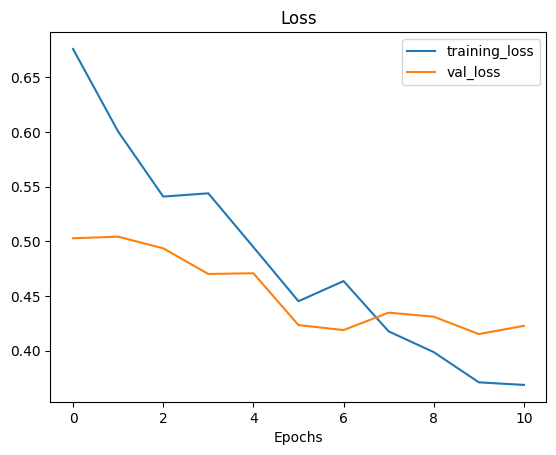

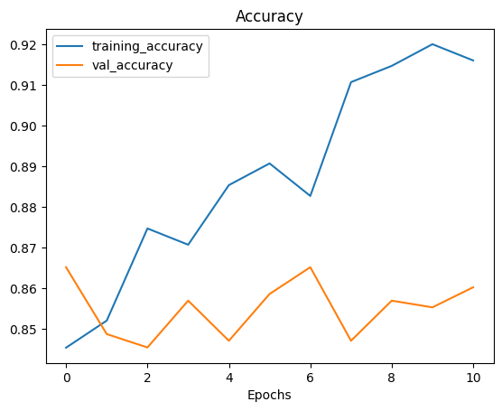

```python
# plot 20 layer fine tune model
plot_loss_curves(history_fine_tune_20_layers)
```

Hmmm, it seems to have really stalled with our valuation data, but the training data has a pretty continual linear behaviour in it's improvement. Model may be entering in a bit of overfitting.

Let's move onto the next step.

### 4. Fine-tune the last 30 layers of the base model you trained in 2 for another 10 epochs. How did it go?

To this, we will basically repeat what we have done on the above, except for one thing we will have to do before training even begins.

We will need to add back the model checkpoint from when we've completed 10 epochs during feature extraction phase.

```python
# re-add checkpoint of model
model.load_weights(checkpoint_path)
```

Now we will unfreeze the top 30 layers of base model, and recompile the model to properly save the changes.

```python
# unfreeze the top 30 layers
for layer in base_model_loc.layers[-30:]: # mistake with -21. chose that number cuz that's what gave'20' trainable variable when printing
    layer.trainable=True

# recompile model
model.compile(loss='categorical_crossentropy',
              optimizer=tf.keras.optimizers.Adam(learning_rate=0.0001),
              metrics=['accuracy'])
```

Let's check if the layers have been unfrozen in the base model.

```python
# check trainability of layers in base model
for layer_number, layer in enumerate(base_model_loc.layers):
    print(layer_number, layer.name, layer.trainable)
```

```
0 input_layer_6 False
1 rescaling_3 False
2 normalization_3 False
3 stem_conv False
4 stem_bn False
5 stem_activation False
6 block1a_project_conv False
7 block1a_project_bn False
8 block1a_project_activation False
9 block2a_expand_conv False
10 block2a_expand_bn False
11 block2a_expand_activation False
12 block2a_project_conv False
13 block2a_project_bn False
14 block2b_expand_conv False
```

[output cut: 255 more lines]

Now let's print out the total variables that are trainable in the model

```python
print(len(model.trainable_variables))
```

```
28
```

The reasoning for it not being '30', when we've unfrozen 30 layers, is maybe because some of the layers within base model is actually not trainable. It could be like an inference point or something, which is not directly influenced by the problem it is tasked to solve.

**NOTE**: It was my mistake to think that if '20' layers are unfrozen, it should have trainable variables of '20'. This is the conclusion I came up with, and strung the idea that `-21` gets me the top 20 layers, when in fact is 21. So unfortunately can't really go back to fix it unless I decided to retrain the `20` layer part. But will keep as an archival of lessons.

Now it's time to fit the model.

```python
# train 10 more epochs on unfrozen 30 layers of the model
total_epochs = 5+10

history_fine_tune_30_layers = model.fit(train_data,
                                        epochs=total_epochs,
                                        validation_data=test_data,
                                        initial_epoch=history_10_percent.epoch[-1],
                                        validation_steps=int(0.25 * len(test_data)),
                                        callbacks=[create_tensorboard_callback('transfer_learning','10_percent_classes')])
```

```
Saving TensorBoard log files to: transfer_learning/10_percent_classes/20251016-211055
24/24 ━━━━━━━━━━━━━━━━━━━━ 52s 1s/step - accuracy: 0.8373 - loss: 0.6909 - val_accuracy: 0.8651 - val_loss: 0.4825
24/24 ━━━━━━━━━━━━━━━━━━━━ 28s 1s/step - accuracy: 0.8707 - loss: 0.6026 - val_accuracy: 0.8454 - val_loss: 0.5401
24/24 ━━━━━━━━━━━━━━━━━━━━ 26s 1s/step - accuracy: 0.8893 - loss: 0.5343 - val_accuracy: 0.8520 - val_loss: 0.4946
24/24 ━━━━━━━━━━━━━━━━━━━━ 26s 1s/step - accuracy: 0.8760 - loss: 0.5018 - val_accuracy: 0.8635 - val_loss: 0.4529
24/24 ━━━━━━━━━━━━━━━━━━━━ 26s 1s/step - accuracy: 0.8880 - loss: 0.4572 - val_accuracy: 0.8651 - val_loss: 0.4553
24/24 ━━━━━━━━━━━━━━━━━━━━ 26s 1s/step - accuracy: 0.9013 - loss: 0.4310 - val_accuracy: 0.8684 - val_loss: 0.4382
24/24 ━━━━━━━━━━━━━━━━━━━━ 28s 1s/step - accuracy: 0.9027 - loss: 0.4096 - val_accuracy: 0.8783 - val_loss: 0.4232
24/24 ━━━━━━━━━━━━━━━━━━━━ 27s 1s/step - accuracy: 0.9133 - loss: 0.3744 - val_accuracy: 0.8734 - val_loss: 0.3926
24/24 ━━━━━━━━━━━━━━━━━━━━ 26s 1s/step - accuracy: 0.9000 - loss: 0.3704 - val_accuracy: 0.8766 - val_loss: 0.4020
24/24 ━━━━━━━━━━━━━━━━━━━━ 26s 1s/step - accuracy: 0.9280 - loss: 0.3439 - val_accuracy: 0.8799 - val_loss: 0.4074
24/24 ━━━━━━━━━━━━━━━━━━━━ 25s 1s/step - accuracy: 0.9267 - loss: 0.3243 - val_accuracy: 0.8799 - val_loss: 0.3804
```

[output not shown]

The above was the result of `20 layer fine tuning` model, being evaluated with the full test data. Let's then see how well `30 layers` did compared to it.

```python
results_fine_tune_30_layers = model.evaluate(test_data)
```

```
79/79 ━━━━━━━━━━━━━━━━━━━━ 37s 473ms/step - accuracy: 0.8796 - loss: 0.3937
```

So it appears that even if more of the top layers were unfrozen, it makes very marginal improvements. It appears we have most likely hit the ceiling in terms of optimization with this particular base model.

Let's check out it's performance visually through graphs to get a better idea on how it improved.

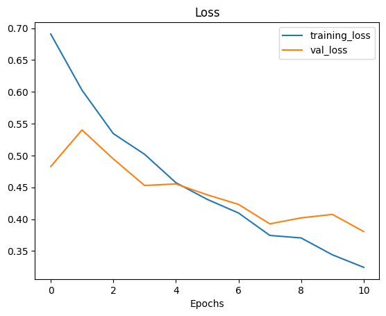

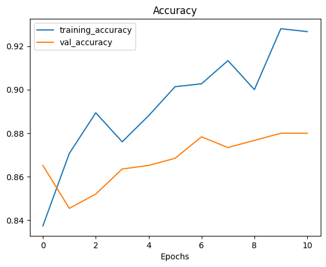

```python
plot_loss_curves(history_fine_tune_30_layers)
```

The graph shows a very similar pattern to the `20 layer fine tune` model. Where the training loss and accuracy, overtakes the validation loss and accuracy. Becoming the more accurate option over the other. Again, overfitting may start to play on the model as its getting too good on training, which can stall or even negatively impact the model's learning habits on unseen data, like our validation images.